# MACHINE LEARNING FOR CAUSAL INFERENCE

Double Lasso, Double Machine Learning, and BART

Marco R. Steenbergen

steenbergen@ipz.uzh.ch

University of Zurich

August 19, 2026

## R Packages for This Lecture

Beyond packages you have installed already, please add

- `MatchIt` for the National Supported Work data we use throughout.
- `hdm` for the (post-)double-selection lasso.
- `DoubleML` for double machine learning.
- `mlr3`, a set of efficient machine learning building blocks.
- `mlr3learners` for using `ranger` and `glmnet` with `DoubleML`.
- `bcf` for Bayesian causal forests.

# The Foundations of Causal Inference

## The Potential Outcomes Framework

### Rubin-Neyman Causal Model (RCM)

For each unit $i$, we define two potential outcomes:

- $Y_i(1)$: Outcome if treated ($W_i = 1$)
- $Y_i(0)$: Outcome if control ($W_i = 0$)

The **Individual Treatment Effect (ITE)** is:
$$\tau_i = Y_i(1) - Y_i(0)$$

(Rubin 1974; Splawa-Neyman et al. 1990).

## What Makes This Well-Defined

**SUTVA**

Writing $Y_i(w)$ at all presupposes the **stable unit treatment value assumption**:

1. **No interference:** unit $i$’s outcome does not depend on the treatments assigned to other units.
2. **No hidden versions of treatment:** “$W_i = 1$” denotes one and the same intervention for everybody.
- SUTVA is an assumption about the *design*, not something machine learning can repair.
- Everything that follows—double lasso, DML, causal forests—takes SUTVA as given.

## The Fundamental Problem of Causal Inference

- We only observe $Y_i = W_i Y_i(1) + (1 - W_i) Y_i(0)$. The counterfactual is never directly observed (Holland 1986).
- However, under certain assumptions it is possible to estimate *average* treatment effects such as:
  - Average treatment effect: $\text{ATE} = \mathbb{E}[Y_i(1) - Y_i(0)]$
  - Average treatment effect on the treated: $\text{ATET} = \mathbb{E}[Y_i(1) - Y_i(0) \mid W_i = 1]$
- The ATET is often the more honest target in observational work: it asks only what the program did for the people who actually took it.

## Our Running Example

### The National Supported Work Demonstration

- NSW was a 1970s US work-experience program for people with severe employment barriers, evaluated by **random assignment** (LaLonde 1986).
- LaLonde (1986) then did something devious: he threw the experimental controls away and replaced them with a survey comparison group (PSID).
- The question: can a non-experimental estimator recover the experimental answer?
- We use the version of these data assembled by Dehejia and Wahba (1999) and shipped with `MatchIt`.

## The Data

- Structure
- Design
- Benchmark

```r
library(MatchIt)
data(lalonde, package = "MatchIt")
str(lalonde)
```

```
'data.frame':   614 obs. of  9 variables:
 $ treat   : int  1 1 1 1 1 1 1 1 1 1 ...
 $ age     : int  37 22 30 27 33 22 23 32 22 33 ...
 $ educ    : int  11 9 12 11 8 9 12 11 16 12 ...
 $ race    : Factor w/ 3 levels "black","hispan",..: 1 2 1 1 1 1 1 1 1 3 ...
 $ married : int  1 0 0 0 0 0 0 0 0 1 ...
 $ nodegree: int  1 1 0 1 1 1 0 1 0 0 ...
 $ re74    : num  0 0 0 0 0 0 0 0 0 0 ...
 $ re75    : num  0 0 0 0 0 0 0 0 0 0 ...
 $ re78    : num  9930 3596 24909 7506 290 ...
```

```r
table(lalonde$treat)
```

```
  0   1
429 185
```

- 185 treated units: the NSW experimental treatment group.
- 429 controls: a comparison sample drawn from the PSID—**not** randomised, and visibly different.
- Outcome `re78`: real earnings in 1978 (US$); `re74`, `re75` are pre-treatment earnings.

The *experimental* NSW contrast (treated vs. randomised controls) is

$$\widehat{\text{ATET}} = 1794 \quad (\text{SE } = 633).$$

Everything we do today is scored against that number.

## Selection Bias and Unconfoundedness

- If we simply compare observed means ($\mathbb{E}[Y \mid W=1] - \mathbb{E}[Y \mid W=0]$), we get:

  $$\text{Naive Difference} = \underbrace{\text{ATET}}_{\mathbb{E}[Y(1) - Y(0)|W = 1]} + \underbrace{\text{Selection Bias}}_{\mathbb{E}[Y(0) \mid W=1] - \mathbb{E}[Y(0) \mid W=0]}$$

  (confounding).
- Key Identification Assumption: **Conditional Ignorability**:

  $$(Y(1), Y(0)) \perp W \mid \boldsymbol{x}$$
- We condition on a set of covariates, $\boldsymbol{x}$.

## The Second Assumption Nobody Writes Down

**Overlap (positivity)**

$$0 < e(\boldsymbol{x}) \equiv \Pr(W = 1 \mid \boldsymbol{x}) < 1 \quad \text{for all } \boldsymbol{x} \text{ in the support}$$

- Ignorability makes the effect *identified*; overlap makes it *estimable*.
- For the ATET the requirement is weaker—we only need $e(\boldsymbol{x}) < 1$, since we never have to find treated counterparts for the controls.
- $e(\boldsymbol{x})$ is the **propensity score** (Rosenbaum and Rubin 1983). We will meet it again as a nuisance function.
- Flexible machine learning makes overlap violations *worse*, not better: a sufficiently rich model can predict treatment almost perfectly, and then the weights explode.

## How Bad Is It Here?

```r
# naive difference in means
coef(summary(lm(re78 ~ treat, data = lalonde)))["treat", 1:2]
```

```
  Estimate Std. Error
 -635.0262   657.1374
```

- The program appears to have *lowered* earnings by about $635.
- The experimental benchmark is $+1794$. The entire gap is selection: the PSID comparison group is older, better educated, more often married, and far richer in 1974–75.

## The Danger of Parametric Controls

In standard empirical workflows, researchers typically write down:
$$Y_i = \beta W_i + \boldsymbol{x}_i^\top \boldsymbol{\gamma} + \epsilon_i$$

**Why this fails in high dimensions**

- **Functional Form Misspecification:** Assuming $g(\boldsymbol{x}) = \boldsymbol{x}^\top \boldsymbol{\gamma}$ is linear leaks omitted variable bias into $\hat{\beta}$ if the true $g(\boldsymbol{x})$ is non-linear or interactive.
- **Curse of Dimensionality:** Adding polynomial terms and interactions quickly leads to over-fitting ($P \approx N$).

## Parametric Controls on NSW

```r
ols <- lm(re78 ~ treat + age + educ + race + married +
            nodegree + re74 + re75, data = lalonde)
coef(summary(ols))["treat", 1:2]
```

```
  Estimate Std. Error
 1548.2438   781.2793
```

- Linear controls move us from $-635$ to $+1548$—most of the way to the benchmark.
- But how much of that is the *right* adjustment and how much is luck in the functional form? Nothing in the output tells us.

> **Key takeaway:** We need methods that control for $\boldsymbol{x}$ flexibly, without smuggling unexamined linearity assumptions into our causal estimates $\Rightarrow$ machine learning.

# The Double Lasso

## The Tempting Shortcut

- Build a rich dictionary of controls—polynomials, interactions, indicators—and let the lasso (Tibshirani 1996) pick the ones that matter for $Y$:

  $$\min_{\beta, \boldsymbol{\gamma}} \; \sum_i (Y_i - \beta W_i - \boldsymbol{x}_i^\top \boldsymbol{\gamma})^2 + \lambda \lVert \boldsymbol{\gamma} \rVert_1$$
- Then re-fit OLS on the selected set and report the usual standard errors.

**This does not work**

The lasso keeps a control only if it predicts $Y$ **strongly enough to beat the penalty**. A confounder that is a moderate predictor of $Y$ but a *powerful* predictor of $W$ gets dropped—and dropping it puts omitted variable bias straight back into $\hat{\beta}$.

## Why the Bias Does Not Vanish

- Regularisation trades variance for bias *by design*. That is fine for prediction; it is fatal for a structural coefficient.
- The omitted-variable bias from a mistakenly excluded control $x_j$ is
  $$\text{bias} \;\approx\; \gamma_j \cdot \frac{\text{Cov}(W, x_j)}{\text{Var}(W)},$$
  which is large exactly when $x_j$ predicts treatment well—the case the lasso is worst at detecting.
- Worse, the post-selection distribution of $\hat{\beta}$ is not the textbook normal: naive standard errors are too small and confidence intervals under-cover, sometimes badly (Leeb and Pötscher 2005).

## Post-Double-Selection

A. Belloni et al. (2014) propose an elegant fix: **select twice**.

1. Run a lasso of $Y$ on $\boldsymbol{x}$. Keep the selected set $\hat{S}_Y$.
2. Run a lasso of $W$ on $\boldsymbol{x}$. Keep the selected set $\hat{S}_W$.
3. Estimate $Y_i = \beta W_i + \boldsymbol{x}_{i,\hat{S}}^\top \boldsymbol{\gamma} + \epsilon_i$ by OLS, where
   $$\hat{S} = \hat{S}_Y \cup \hat{S}_W.$$
4. Report conventional heteroskedasticity-robust standard errors for $\hat{\beta}$.

**Tip**

The union in step 3 is the whole idea: a variable only escapes if it is unimportant for *both* equations.

## Why the Union Immunises You

### The intuition

Any control that could bias $\hat{\beta}$ must be correlated with $W$. Step 2 is a dedicated search for exactly those variables, so a confounder has to survive two independent screens to be dropped.

### The theory

Double selection makes the estimating equation **Neyman-orthogonal**: small errors in the two selection steps have zero first-order effect on $\hat{\beta}$, so $\hat{\beta}$ is $\sqrt{N}$-consistent and asymptotically normal (Alexandre Belloni et al. 2014).

- Equivalently, it is Frisch–Waugh–Lovell done twice: residualise $Y$ *and* $W$ before comparing them.

## What You Still Have to Assume

**The fine print**

- **Approximate sparsity:** both $\mathbb{E}[Y \mid \boldsymbol{x}]$ and $\mathbb{E}[W \mid \boldsymbol{x}]$ are well approximated by $s$ terms of the dictionary, with $s \ll N / \log P$.
- **Linearity in the dictionary:** the true functions must lie (approximately) in the span of the terms you supplied. Double lasso does not discover interactions you never wrote down.
- **Ignorability and overlap** are unchanged. Selection over observables cannot fix unobserved confounding.
- Practical corollary: the dictionary is a modelling decision, and a generous one is safer than a stingy one.

## Building the Dictionary

```r
form_x <- ~ (age + educ + race + married + nodegree + re74 + re75)^2 +
  I(age^2) + I(age^3) + I(educ^2) + I(re74^2) + I(re75^2) +
  I(re74 == 0) + I(re75 == 0) - 1
X <- model.matrix(form_x, data = lalonde)
X <- X[, apply(X, 2, sd) > 0]       # drop degenerate columns
y <- lalonde$re78
d <- lalonde$treat
dim(X)
```

```
[1] 614  43
```

- All pairwise interactions, some polynomials, and indicators for zero earnings in 1974/75 (a well-known marker of the NSW target population).

## Illustration in R

- Single selection
- Double selection
- What changed
- `hdm`
- Partialling out

```r
library(hdm)
sel_y <- which(coef(rlasso(X, y))[-1] != 0)   # outcome equation only
colnames(X)[sel_y]
```

```
[1] "I(re74^2)"      "educ:re75"      "racewhite:re74" "racewhite:re75"
[5] "married:re74"   "re74:re75"
```

```r
coef(summary(lm(y ~ d + X[, sel_y])))["d", 1:2]
```

```
  Estimate Std. Error
  1225.439    649.455
```

```r
sel_d <- which(coef(rlasso(X, d))[-1] != 0)   # treatment equation
colnames(X)[sel_d]
```

```
[1] "raceblack"         "racewhite"         "I(re74 == 0)TRUE"
[4] "age:married"       "racewhite:married"
```

```r
S <- union(sel_y, sel_d)
coef(summary(lm(y ~ d + X[, S])))["d", 1:2]
```

```
  Estimate Std. Error
 1078.6250   788.5312
```

- The two selected sets are **disjoint**. Race and the “no 1974 earnings” indicator predict *treatment* strongly but were invisible to the outcome lasso.
- The estimate moves from $1225$ to $1079$, and the standard error grows from $650$ to $789$.
- That larger standard error is the honest one: single selection was pretending to know which controls belonged in the model.

```r
pds <- rlassoEffect(x = X, y = y, d = d, method = "double selection")
summary(pds)
```

```
[1] "Estimates and significance testing of the effect of target variables"
   Estimate. Std. Error t value Pr(>|t|)
d1    1078.6      721.1   1.496    0.135
```

```r
confint(pds)
```

```
       2.5 %   97.5 %
d1 -334.6532 2491.903
```

```r
po <- rlassoEffect(x = X, y = y, d = d, method = "partialling out")
summary(po)
```

```
[1] "Estimates and significance testing of the effect of target variables"
     Estimate. Std. Error t value Pr(>|t|)
[1,]    1150.4      785.3   1.465    0.143
```

The partialling-out variant residualises $Y$ and $W$ on the lasso fits directly rather than re-fitting OLS on the union. Same theory, slightly different finite-sample behaviour.

## Where Double Lasso Runs Out

- It is still a **linear** method: everything non-linear must be supplied by hand in the dictionary.
- Selection is a hard thresholding rule, which behaves badly when several controls are strongly collinear—a real risk once you add all pairwise interactions.
- It gives one number, $\hat{\beta}$, under a constant-effect assumption.

> The natural next question: can we keep the double structure but replace the lasso with *any* machine learner?

# Double Machine Learning

## The Historical Anchor

- Robinson (1988) introduced the partially linear model:

  $$Y = \beta W + g(\boldsymbol{x}) + U, \quad \mathbb{E}[U \mid W, \boldsymbol{x}] = 0$$

  where $g(\boldsymbol{x})$ is an **unknown, fully non-parametric function**.
- Robinson’s residualisation algorithm:
  1. Compute conditional expectations: $m(\boldsymbol{x}) = \mathbb{E}[Y \mid \boldsymbol{x}]$ and $e(\boldsymbol{x}) = \mathbb{E}[W \mid \boldsymbol{x}]$.
  2. Construct residuals: $\tilde{Y} = Y - m(\boldsymbol{x})$ and $\tilde{W} = W - e(\boldsymbol{x})$.
  3. Regress $\tilde{Y}$ on $\tilde{W}$ using OLS to obtain a $\sqrt{N}$-consistent estimate of $\beta$.

## Upgrading Robinson: Double Machine Learning (DML)

- Robinson (1988) used 1980s kernel smoothers, whose convergence rate degrades sharply once $\boldsymbol{x}$ has more than three or four continuous variables.
- Modern solution (Chernozhukov et al. 2018):
  - Replace kernel smoothers with modern ML algorithms (random forests, boosting, neural nets, or indeed the lasso).
- We call this **double** machine learning because we have two predictive tasks:
  - Predicting $Y$ from controls.
  - Predicting $W$ from controls.

**Note**

Double lasso is the special case in which both learners are lassos and the residualisation is done by selection rather than by prediction.

## Core Mechanisms

### 1. Cross-fitting (sample splitting)

Split the sample into $K$ folds. Fit $\hat{m}$ and $\hat{e}$ on the other $K-1$ folds, predict on the held-out fold, then rotate and average over folds. This removes the over-fitting bias created by using the same observations to estimate the nuisance functions and the effect.

### 2. Neyman orthogonality

The moment condition is constructed so that its derivative with respect to the nuisance functions is zero at the truth. Small mistakes in $\hat{m}, \hat{e}$ therefore produce **no first-order bias** in $\hat{\beta}$.

## The Rate Condition

**What “small mistakes” means**

Orthogonality is not magic—it buys you a *rate*, not immunity. The theory requires

$$\lVert \hat{m} - m \rVert_2 \cdot \lVert \hat{e} - e \rVert_2 = o_P(N^{-1/2}),$$

which is typically delivered if each nuisance function is estimated at rate $o_P(N^{-1/4})$.

- $N^{-1/4}$ is far slower than the parametric $N^{-1/2}$, and many ML estimators achieve it under sparsity or smoothness.
- But it is *not* free: a badly tuned forest or a hopeless propensity model still breaks the estimator.

## Two Models, Two Estimands

### Partially linear (PLR)

$$Y = \beta W + g(\boldsymbol{x}) + U$$

Assumes the effect is a **constant** $\beta$. Efficient, stable, and the natural generalisation of Robinson.

### Interactive (IRM)

$$Y = g(W, \boldsymbol{x}) + U$$

Puts no restriction on how $W$ interacts with $\boldsymbol{x}$; identifies the ATE or ATET through the doubly robust (AIPW) score.

- With a **binary** treatment, PLR does not estimate the ATE unless effects really are constant—it returns a particular variance-weighted average of $\tau(\boldsymbol{x})$.
- Use the IRM when the estimand matters; use the PLR when you want one well-behaved summary number (Knaus et al. 2021).

## Illustration in R

- Data object
- Learners
- PLR
- IRM / ATET

```r
library(DoubleML); library(mlr3); library(mlr3learners)
lgr::get_logger("mlr3")$set_threshold("warn")  # silence learner chatter

nsw <- lalonde
nsw$black  <- as.integer(nsw$race == "black")
nsw$hispan <- as.integer(nsw$race == "hispan")
nsw$race   <- NULL

x_cols <- c("age", "educ", "black", "hispan", "married",
            "nodegree", "re74", "re75")
dml_data <- DoubleMLData$new(nsw, y_col = "re78",
                             d_cols = "treat", x_cols = x_cols)
```

Note that we hand the *raw* covariates to the forest: unlike the lasso, it builds its own interactions.

```r
set.seed(2026)
ml_l <- lrn("regr.ranger",    num.trees = 500,      # E[Y|X]
            min.node.size = 5)
ml_m <- lrn("classif.ranger", num.trees = 500,      # E[W|X]
            min.node.size = 5, predict_type = "prob")
```

Because $W$ is binary, the second nuisance function is a **classifier** returning probabilities, not a regressor.

```r
plr <- DoubleMLPLR$new(dml_data, ml_l = ml_l, ml_m = ml_m,
                       n_folds = 5, n_rep = 5)
plr$fit()
plr$summary()
```

```
Estimates and significance testing of the effect of target variables
      Estimate. Std. Error t value Pr(>|t|)
treat     858.6      777.0   1.105    0.269
```

`n_rep = 5` repeats the whole cross-fitting exercise with different splits and aggregates, so the answer does not hinge on one lucky partition.

```r
set.seed(2026)
irm <- DoubleMLIRM$new(
  dml_data,
  ml_g = lrn("regr.ranger", num.trees = 500, min.node.size = 5),
  ml_m = lrn("classif.ranger", num.trees = 500, min.node.size = 5,
             predict_type = "prob"),
  n_folds = 5, n_rep = 5,
  score = "ATTE", trimming_threshold = 0.01)
irm$fit()
irm$summary()
```

```
Estimates and significance testing of the effect of target variables
      Estimate. Std. Error t value Pr(>|t|)
treat     629.7      876.5   0.718    0.473
```

## Diagnosing Overlap

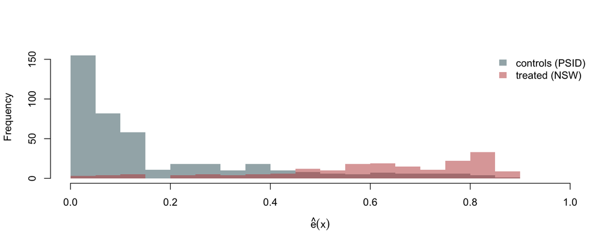

```r
library(ranger)
set.seed(2026)
ehat <- ranger(factor(treat) ~ ., data = nsw[, c("treat", x_cols)],
               probability = TRUE, num.trees = 1000)$predictions[, 2]

hist(ehat[nsw$treat == 0], breaks = 30, col = "#40666e88", border = NA,
     xlim = c(0, 1), main = "", xlab = expression(hat(e)(x)))
hist(ehat[nsw$treat == 1], breaks = 30, col = "#c0504d88",
     border = NA, add = TRUE)
legend("topright", c("controls (PSID)", "treated (NSW)"), bty = "n",
       fill = c("#40666e88", "#c0504d88"), border = NA)
```

## Overlap, Continued

```r
mean(ehat[nsw$treat == 0] < 0.05)   # controls with no plausible counterpart
```

```
[1] 0.3613054
```

## Scoring the Methods

| Method | Estimate | SE |
| --- | --- | --- |
| Experimental benchmark (NSW) | 1794 | 633 |
| Naive difference in means | -635 | 657 |
| OLS, linear controls | 1548 | 781 |
| Lasso, outcome equation only | 1225 | 649 |
| Post-double-selection lasso | 1079 | 721 |
| Partialling-out lasso | 1150 | 785 |
| DML, partially linear (RF) | 859 | 777 |
| DML, interactive / ATET (RF) | 630 | 877 |

## Reading the Table

**The lesson for your own work**

Report the naive contrast, the parametric adjustment, and the orthogonal estimate side by side. Where they disagree, the disagreement is the finding.

# Heterogeneous Treatment Effects

## Beyond Constant Treatment Effects

- So far, we have assumed there is a single $\beta$ that describes all sub-groups equally well.
- However, treatment effects usually vary.
- How do we build that into machine learning?

## The Meta-Learner Taxonomy

| Learner | Estimator Strategy | Target Objective |
| --- | --- | --- |
| **S-Learner** | Single model $\hat{\mu}(\boldsymbol{x}, W)$ | Predict $Y$ directly; subtract predictions |
| **T-Learner** | Two models: $\hat{\mu}_1(\boldsymbol{x})$ and $\hat{\mu}_0(\boldsymbol{x})$ | Model $W=1$ and $W=0$ independently |
| **X-Learner** | Uses imputed counterfactuals | Designed for extreme treatment imbalance |
| **R-Learner** | Minimizes Robinson’s R-Loss | Directly optimizes $(\tilde{Y} - \tilde{W}\tau(\boldsymbol{x}))^2$ |

## The Meta-Learner Taxonomy Cont’d

| Learner | Use Cases | Weaknesses |
| --- | --- | --- |
| **S-Learner** | (1) Multi-valued or continuous $W$; (2) RCTs with minimal confounding. | Regularization bias: Trees and regularized models tend to shrink treatment effects toward 0 if main covariate effects dominate $Y$. |
| **T-Learner** | (1) Balanced data sets; (2) when you want to ensure $W$ is not ignored. | Inefficient when sample sizes are imbalanced between arms; zero information sharing between arms. |
| **X-Learner** | Severe treatment imbalance. | Computationally heavy. |
| **R-Learner** | Large observational studies requiring **double robustness** (unbiased if *either* the propensity model or outcome model is correctly specified). | Pseudo-outcomes can become volatile and unstable if estimated propensity scores get dangerously close to 0 or 1. |

## Causal Forests

- Athey et al. (2019) extend Robinson’s residualization trick to **local adaptive neighborhood**.
- Procedure
  1. Compute global ML predictions $\hat{m}(\boldsymbol{x})$ and $\hat{e}(\boldsymbol{x})$ to obtain residuals $\tilde{Y}$ and $\tilde{W}$.
  2. Recursively split the feature space into leaf nodes that **maximize heterogeneity** in treatment effect estimates.
  3. Compute locally weighted OLS inside each leaf:

     $$\hat{\tau}(\boldsymbol{x}) = \frac{\sum_{i \in L(x)} \alpha_i(\boldsymbol{x}) \tilde{Y}_i \tilde{W}_i}{\sum_{i \in L(x)} \alpha_i(\boldsymbol{x}) \tilde{W}_i^2}$$
- DR-learning

## Causal Forests Cont’d

> To preserve valid asymptotic inference, trees use separate sub-samples for deciding split locations versus estimating leaf-level treatment effects.

## Regularization-Induced Confounding (RIC)

- In observational studies, when confounding is strong, standard ML trees confuse baseline prognostic variation ($Y(0)$) with treatment heterogeneity ($\tau(\boldsymbol{x})$) (Hahn et al. 2020).
- For instance,
  - A job-training program has a true positive effect.
  - However, the treatment indicator is greedily used as a shortcut to capture baseline wage differences driven by confounding rather than treatment heterogeneity.
  - As a result the causal effect is shrunk to 0.

## Bayesian Causal Forests

- Hahn et al. (2020) propose Bayesian causal forests (BCF) as a way out off RIC.
- BCF modifies the BART prior:

  $$Y_i = \mu(\boldsymbol{x}_i, \hat{\pi}(\boldsymbol{x}_i)) + W_i \cdot \tau(\boldsymbol{x}_i) + \epsilon_i$$
- Specifically,
  - **Explicit propensity entry:** Including $\hat{\pi}(\boldsymbol{x})$ directly into $\mu(\cdot)$ absorbs baseline confounding.
  - **Targeted shrinkage:** Applies strong regularization on $\tau(\boldsymbol{x})$ (shrinks to homogeneity) while allowing $\mu(\boldsymbol{x})$ to stay flexible.

## A Hybrid

- **Like a T-Learner / X-Learner:** BCF explicitly separates the treatment groups/effects from the baseline, avoiding the naive blurring of an S-learner.
- **Like an R-Learner / DR-Learner:** BCF directly incorporates an estimated propensity score $\hat{\pi}(\boldsymbol{x})$ into the model architecture to neutralize confounding.

## Illustration

- DGP
- Estimation

```r
# data generating process
set.seed(19)

p = 3 # three control variables
n = 250

x = matrix(rnorm(n*p), nrow=n)

# create targeted selection
q = -1*(x[,1]>(x[,2])) + 1*(x[,1]<(x[,2]))

# generate treatment variable
pi = pnorm(q)
w = rbinom(n,1,pi)

# tau is the true (heterogeneous) treatment effect
tau = (0.5*(x[,3] > -3/4) + 0.25*(x[,3] > 0) + 0.25*(x[,3]>3/4))

# generate the response using q, tau and w
mu = (q + tau*w)

# set the noise level relative to the expected mean function of Y
sigma = diff(range(q + tau*pi))/8

# draw the response variable with additive error
y = mu + sigma*rnorm(n)
```

```r
library(bcf)
# If you didn't know pi, you would estimate it here
pihat = pnorm(q)

n_burn = 5000
n_sim = 5000

bcf_fit = bcf(y               = y,
              z               = w,
              x_control       = x,
              x_moderate      = x,
              pihat           = pihat,
              nburn           = n_burn,
              nsim            = n_sim,
              n_chains        = 2,
              update_interval = 100,
              save_tree_directory = './trees')
```

## References

Athey, Susan, Julie Tibshirani, and Stefan Wager. 2019. “Generalized Random Forests.” *The Annals of Statistics* 47 (2). https://doi.org/10.1214/18-AOS1709.

Belloni, A., V. Chernozhukov, and C. Hansen. 2014. “Inference on Treatment Effects After Selection Among High-Dimensional Controls.” *The Review of Economic Studies* 81 (2): 608–50. https://doi.org/10.1093/restud/rdt044.

Belloni, Alexandre, Victor Chernozhukov, and Christian Hansen. 2014. “High-Dimensional Methods and Inference on Structural and Treatment Effects.” *Journal of Economic Perspectives* 28 (2): 29–50. https://doi.org/10.1257/jep.28.2.29.

Chernozhukov, Victor, Denis Chetverikov, Mert Demirer, et al. 2018. “Double/Debiased Machine Learning for Treatment and Structural Parameters.” *The Econometrics Journal* 21 (1): C1–68. https://doi.org/10.1111/ectj.12097.

Dehejia, Rajeev H., and Sadek Wahba. 1999. “Causal Effects in Nonexperimental Studies: Reevaluating the Evaluation of Training Programs.” *Journal of the American Statistical Association* 94 (448): 1053–62. https://doi.org/10.2307/2669919.

Hahn, P. Richard, Jared S. Murray, and Carlos M. Carvalho. 2020. “Bayesian Regression Tree Models for Causal Inference: Regularization, Confounding, and Heterogeneous Effects (with Discussion).” *Bayesian Analysis* 15 (3). https://doi.org/10.1214/19-BA1195.

Holland, Paul W. 1986. “Statistics and Causal Inference.” *Journal of the American Statistical Association* 81 (396): 945–60. https://doi.org/10.2307/2289064.

Knaus, Michael C, Michael Lechner, and Anthony Strittmatter. 2021. “Machine Learning Estimation of Heterogeneous Causal Effects: Empirical Monte Carlo Evidence.” *The Econometrics Journal* 24 (1): 134–61. https://doi.org/10.1093/ectj/utaa014.

LaLonde, Robert J. 1986. “Evaluating the Econometric Evaluations of Training Programs with Experimental Data.” *The American Economic Review* 76 (4): 604–20.

Leeb, Hannes, and Benedikt M. Pötscher. 2005. “Model Selection and Inference: Facts and Fiction.” *Econometric Theory* 21 (1): 21–59. https://doi.org/10.1017/S0266466605050036.

Robinson, P. M. 1988. “Root-N-Consistent Semiparametric Regression.” *Econometrica* 56 (4): 931. https://doi.org/10.2307/1912705.

Rosenbaum, Paul R., and Donald B. Rubin. 1983. “The Central Role of the Propensity Score in Observational Studies for Causal Effects.” *Biometrika* 70 (1): 41–55. https://doi.org/10.2307/2335942.

Rubin, Donald B. 1974. “Estimating Causal Effects of Treatments in Randomized and Nonrandomized Studies.” *Journal of Educational Psychology* 66 (5): 688–701. https://doi.org/10.1037/h0037350.

Splawa-Neyman, Jerzy, D. M. Dabrowska, and T. P. Speed. 1990. “On the Application of Probability Theory to Agricultural Experiments. Essay on Principles. Section 9.” *Statistical Science* 5 (4). https://doi.org/10.1214/ss/1177012031.

Tibshirani, Robert. 1996. “Regression Shrinkage and Selection Via the Lasso.” *Journal of the Royal Statistical Society Series B: Statistical Methodology* 58 (1): 267–88. https://doi.org/10.1111/j.2517-6161.1996.tb02080.x.